# Project_Machine Learning_Personal Loan Campaign

### Context

AllLife Bank is a US bank that has a growing customer base. The majority of these customers are liability customers (depositors) with varying sizes of deposits. The number of customers who are also borrowers (asset customers) is quite small, and the bank is interested in expanding this base rapidly to bring in more loan business and in the process, earn more through the interest on loans. In particular, the management wants to explore ways of converting its liability customers to personal loan customers (while retaining them as depositors).

A campaign that the bank ran last year for liability customers showed a healthy conversion rate of over 9% success. This has encouraged the retail marketing department to devise campaigns with better target marketing to increase the success ratio.

You as a Data Scientist at AllLife Bank have to build a model that will help the marketing department to identify the potential customers who have a higher probability of purchasing the loan.

Objective To predict whether a liability customer will buy personal loans, to understand which customer attributes are most significant in driving purchases, and to identify which segment of customers to target more.

### Data Dictionary

ID: Customer ID

Age: Customer’s age in completed years

Experience: # years of professional experience

Income: Annual income of the customer (in thousand dollars)

ZIP Code: Home Address ZIP code.

Family: The family size of the customer

CCAvg: Average spending on credit cards per month (in thousand dollars)

Education: Education Level. 1: Undergrad; 2: Graduate;3: Advanced/Professional

Mortgage: Value of house mortgage if any. (in thousand dollars)

Personal_Loan: Did this customer accept the personal loan offered in the last campaign?

Securities_Account: Does the customer have a securities account with the bank?

CD_Account: Does the customer have a certificate of deposit (CD) account with the bank?

Online: Do customers use Internet banking facilities?

CreditCard: Does the customer use a credit card issued by any other Bank (excluding All Life Bank)?

## Data pre-processing

```python
# Importing necessary library.

import warnings
warnings.filterwarnings("ignore")

import pandas as pd
import numpy as np
import seaborn as sns
import matplotlib.pyplot as plt
sns.set_theme(style="whitegrid")
%matplotlib inline
```

```python
# Reading the csv file.
data = pd.read_csv("Loan_Modelling.csv")
```

```python
# Making the copy of original data for further analysis.
df = data.copy()
```

```python
df.head()
```

|  | ID | Age | Experience | Income | ZIPCode | Family | CCAvg | Education | Mortgage | Personal_Loan | Securities_Account | CD_Account | Online | CreditCard |
| --- | --- | --- | --- | --- | --- | --- | --- | --- | --- | --- | --- | --- | --- | --- |
| 0 | 1 | 25 | 1 | 49 | 91107 | 4 | 1.6 | 1 | 0 | 0 | 1 | 0 | 0 | 0 |
| 1 | 2 | 45 | 19 | 34 | 90089 | 3 | 1.5 | 1 | 0 | 0 | 1 | 0 | 0 | 0 |
| 2 | 3 | 39 | 15 | 11 | 94720 | 1 | 1.0 | 1 | 0 | 0 | 0 | 0 | 0 | 0 |
| 3 | 4 | 35 | 9 | 100 | 94112 | 1 | 2.7 | 2 | 0 | 0 | 0 | 0 | 0 | 0 |
| 4 | 5 | 35 | 8 | 45 | 91330 | 4 | 1.0 | 2 | 0 | 0 | 0 | 0 | 0 | 1 |

```python
# Checking the shape of the data.
df.shape
```

```
(5000, 14)
```

```python
# Checking the statistical summary of the dataset.
df.describe()
```

|  | ID | Age | Experience | Income | ZIPCode | Family | CCAvg | Education | Mortgage | Personal_Loan | Securities_Account | CD_Account | Online | CreditCard |
| --- | --- | --- | --- | --- | --- | --- | --- | --- | --- | --- | --- | --- | --- | --- |
| count | 5000.000000 | 5000.000000 | 5000.000000 | 5000.000000 | 5000.000000 | 5000.000000 | 5000.000000 | 5000.000000 | 5000.000000 | 5000.000000 | 5000.000000 | 5000.00000 | 5000.000000 | 5000.000000 |
| mean | 2500.500000 | 45.338400 | 20.104600 | 73.774200 | 93169.257000 | 2.396400 | 1.937938 | 1.881000 | 56.498800 | 0.096000 | 0.104400 | 0.06040 | 0.596800 | 0.294000 |
| std | 1443.520003 | 11.463166 | 11.467954 | 46.033729 | 1759.455086 | 1.147663 | 1.747659 | 0.839869 | 101.713802 | 0.294621 | 0.305809 | 0.23825 | 0.490589 | 0.455637 |
| min | 1.000000 | 23.000000 | -3.000000 | 8.000000 | 90005.000000 | 1.000000 | 0.000000 | 1.000000 | 0.000000 | 0.000000 | 0.000000 | 0.00000 | 0.000000 | 0.000000 |
| 25% | 1250.750000 | 35.000000 | 10.000000 | 39.000000 | 91911.000000 | 1.000000 | 0.700000 | 1.000000 | 0.000000 | 0.000000 | 0.000000 | 0.00000 | 0.000000 | 0.000000 |
| 50% | 2500.500000 | 45.000000 | 20.000000 | 64.000000 | 93437.000000 | 2.000000 | 1.500000 | 2.000000 | 0.000000 | 0.000000 | 0.000000 | 0.00000 | 1.000000 | 0.000000 |
| 75% | 3750.250000 | 55.000000 | 30.000000 | 98.000000 | 94608.000000 | 3.000000 | 2.500000 | 3.000000 | 101.000000 | 0.000000 | 0.000000 | 0.00000 | 1.000000 | 1.000000 |
| max | 5000.000000 | 67.000000 | 43.000000 | 224.000000 | 96651.000000 | 4.000000 | 10.000000 | 3.000000 | 635.000000 | 1.000000 | 1.000000 | 1.00000 | 1.000000 | 1.000000 |

### Observations :

**Experience anomaly:**

Minimum experience is -3 years, which is invalid → needs cleaning (possibly data entry or calculation error).

**Income distribution:**

Mean income ≈ $73.8K, with a wide range (8K–224K).

Skewed towards higher earners (as mean > median 64K).

**Family size:**

Average family size is ~2.4, with max 4 members.

**Credit card spending (CCAvg):**

Average monthly credit card spending ≈ $1.94K, but some spend upto 10K.

**Education level:**

Coded as 1–3 (likely 1 = Undergraduate, 2 = Graduate, 3 = Advanced/Professional).

**Mortgage:**

56.5 average mortgage, but median is 0 → many customers have no mortgage.

**Personal Loan acceptance:**

Only 9.6% accepted personal loans → data is imbalanced (important for ML modeling).

```python
# Checking the missing values in the dataset
df.isnull().sum()
```

```
ID                    0
Age                   0
Experience            0
Income                0
ZIPCode               0
Family                0
CCAvg                 0
Education             0
Mortgage              0
Personal_Loan         0
Securities_Account    0
CD_Account            0
Online                0
CreditCard            0
dtype: int64
```

### Observation :

There is no missing vlaue in the dataset.

```python
# Checking the data info
df.info()
```

```
<class 'pandas.core.frame.DataFrame'>
RangeIndex: 5000 entries, 0 to 4999
Data columns (total 14 columns):
 #   Column              Non-Null Count  Dtype
---  ------              --------------  -----
 0   ID                  5000 non-null   int64
 1   Age                 5000 non-null   int64
 2   Experience          5000 non-null   int64
 3   Income              5000 non-null   int64
 4   ZIPCode             5000 non-null   int64
 5   Family              5000 non-null   int64
 6   CCAvg               5000 non-null   float64
 7   Education           5000 non-null   int64
 8   Mortgage            5000 non-null   int64
 9   Personal_Loan       5000 non-null   int64
 10  Securities_Account  5000 non-null   int64
 11  CD_Account          5000 non-null   int64
 12  Online              5000 non-null   int64
 13  CreditCard          5000 non-null   int64
dtypes: float64(1), int64(13)
memory usage: 547.0 KB
```

### Observation :

All columns are numeric (int64 or float64), so preprocessing for ML (like scaling, encoding) will be straightforward.

## Exploratory Data Analysis (EDA)

## Univariate Analysis

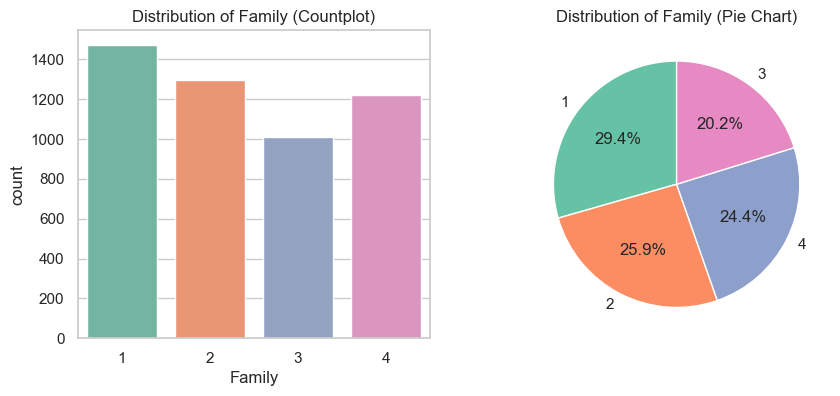

```python
# Plotting the Family variable to see the distribution
plt.figure(figsize=(10,4))
plt.subplot(1,2,1)
sns.countplot(data = df, x = "Family", palette="Set2")
plt.title(f"Distribution of Family (Countplot)")

plt.subplot(1,2,2)
df["Family"].value_counts().plot.pie(autopct='%1.1f%%', colors=sns.color_palette("Set2"), startangle=90)
plt.ylabel('')
plt.title(f"Distribution of Family (Pie Chart)")
plt.show()
```

### Observations:

Both the countplot and the pie chart indicate that most families fall into family size of 1 and 2, while family size of 3 represents the smallest proportion.

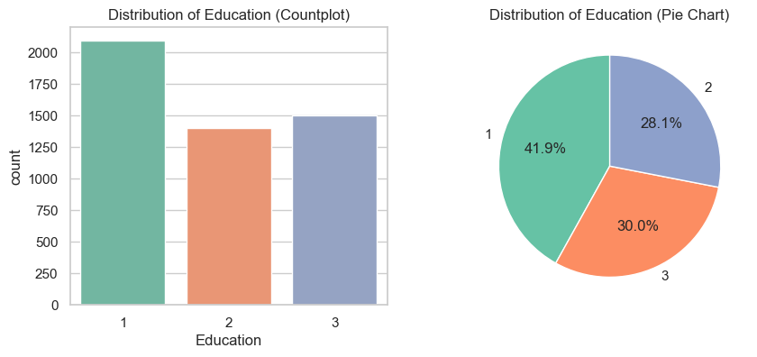

```python
# Plotting the Education variable to see the distribution
plt.figure(figsize=(10,4))
plt.subplot(1,2,1)
sns.countplot(data = df, x = "Education", palette="Set2")
plt.title(f"Distribution of Education (Countplot)")

plt.subplot(1,2,2)
df["Education"].value_counts().plot.pie(autopct='%1.1f%%', colors=sns.color_palette("Set2"), startangle=90)
plt.ylabel('')
plt.title(f"Distribution of Education (Pie Chart)")
plt.show()
```

### Obervation:

From the distribution it is clear that most number of bank customer are Undergrad around (41.9%), followed by the bank customer with Advanced/Professional qualification around (30.0%) and Graduate around (28.1%)

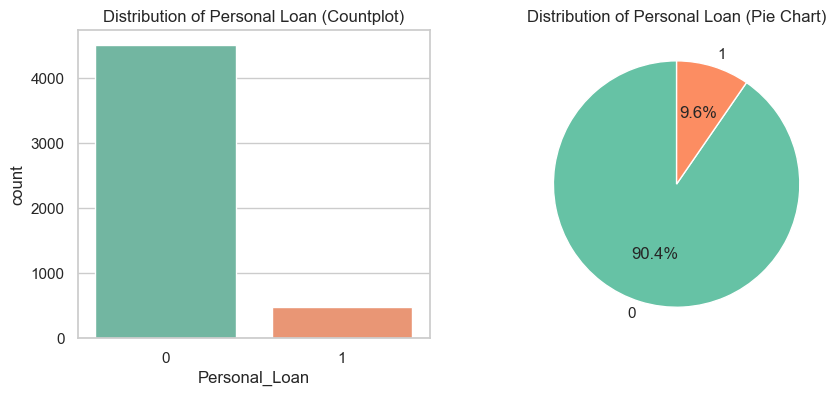

```python
# Plotting the Personal_Loan variable to see the distribution
plt.figure(figsize=(10,4))
plt.subplot(1,2,1)
sns.countplot(data = df, x = "Personal_Loan", palette="Set2")
plt.title(f"Distribution of Personal Loan (Countplot)")

plt.subplot(1,2,2)
df["Personal_Loan"].value_counts().plot.pie(autopct='%1.1f%%', colors=sns.color_palette("Set2"), startangle=90)
plt.ylabel('')
plt.title(f"Distribution of Personal Loan (Pie Chart)")
plt.show()
```

### Obervations:

Only 9.6% customers has accepted the loan offer in last campaign.

Since this is target variable and the data is imbalance, need treatment in further analysis.

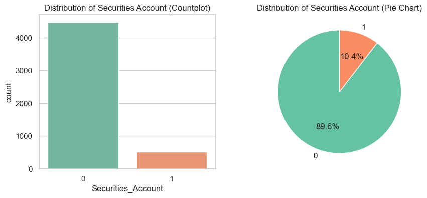

```python
# Plotting the Securities_Account variable to see the distribution
plt.figure(figsize=(10,4))
plt.subplot(1,2,1)
sns.countplot(data = df, x = "Securities_Account", palette="Set2")
plt.title(f"Distribution of Securities Account (Countplot)")

plt.subplot(1,2,2)
df["Securities_Account"].value_counts().plot.pie(autopct='%1.1f%%', colors=sns.color_palette("Set2"), startangle=90)
plt.ylabel('')
plt.title(f"Distribution of Securities Account (Pie Chart)")
plt.show()
```

### Observations:

Arround 500 (10.4%) bank customers hold securities account with the bank.

89.6% around 4500 bank customers do not hold securities account with the bank.

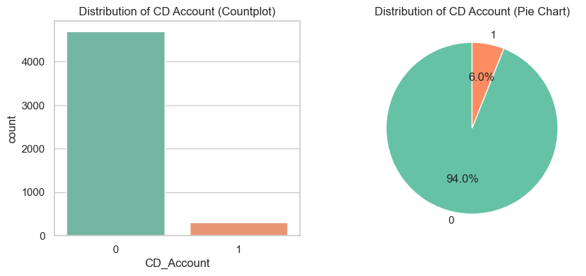

```python
# Plotting the CD_Account variable to see the distribution
plt.figure(figsize=(10,4))
plt.subplot(1,2,1)
sns.countplot(data = df, x = "CD_Account", palette="Set2")
plt.title(f"Distribution of CD Account (Countplot)")

plt.subplot(1,2,2)
df["CD_Account"].value_counts().plot.pie(autopct='%1.1f%%', colors=sns.color_palette("Set2"), startangle=90)
plt.ylabel('')
plt.title(f"Distribution of CD Account (Pie Chart)")
plt.show()
```

### Observation:

Only 6.0% of the bank customers have certificate of deposit (CD) account with the bank.

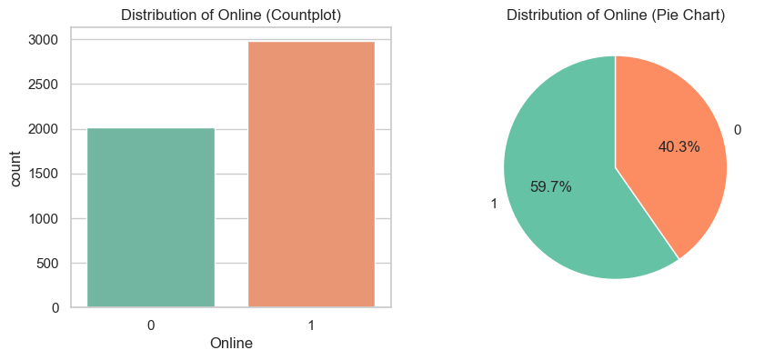

```python
# Plotting the Online variable to see the distribution
plt.figure(figsize=(10,4))
plt.subplot(1,2,1)
sns.countplot(data = df, x = "Online", palette="Set2")
plt.title(f"Distribution of Online (Countplot)")

plt.subplot(1,2,2)
df["Online"].value_counts().plot.pie(autopct='%1.1f%%', colors=sns.color_palette("Set2"), startangle=90)
plt.ylabel('')
plt.title(f"Distribution of Online (Pie Chart)")
plt.show()
```

### Observations:

59.7% of bank customers are using Internet banking facilities which is arround 3000 customers.

40.3% around 2000 bank customer are not using Internet banking facilities.

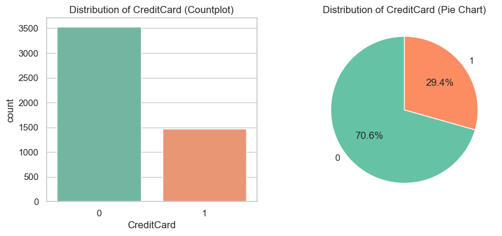

```python
# Plotting the CreditCard variable to see the distribution
plt.figure(figsize=(10,4))
plt.subplot(1,2,1)
sns.countplot(data = df, x = "CreditCard", palette="Set2")
plt.title(f"Distribution of CreditCard (Countplot)")

plt.subplot(1,2,2)
df["CreditCard"].value_counts().plot.pie(autopct='%1.1f%%', colors=sns.color_palette("Set2"), startangle=90)
plt.ylabel('')
plt.title(f"Distribution of CreditCard (Pie Chart)")
plt.show()
```

### Observation:

Only 29.4% of bank customer are using credit card.

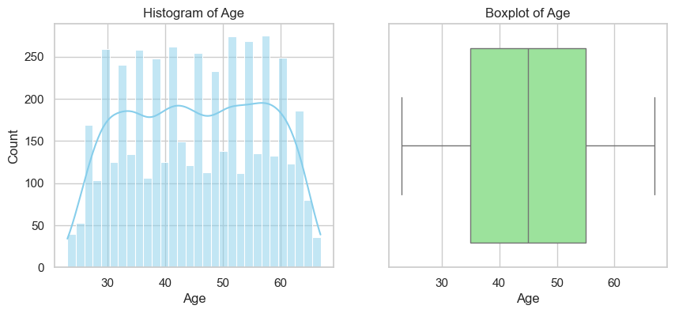

```python
# Plotting Age variable to see the distribution.
plt.figure(figsize = (10,4))
plt.subplot(1,2,1)
sns.histplot(df["Age"], kde = True, bins = 30, color = "skyblue")
plt.title("Histogram of Age")

plt.subplot(1,2,2)
sns.boxplot(x=df["Age"], color = "lightgreen")
plt.title("Boxplot of Age")
plt.show()
```

### Observations:

The age distribution appears to be approximately uniform, with individuals spread fairly evenly between ages 25 and 65.

The histogram shows no significant skewness, suggesting a balanced age distribution without dominant peaks.

The boxplot indicates that the median age is around 45 years, and most values lie between 30 and 60 years, showing a moderate spread.

There are no major outliers, implying a clean and consistent data range for the Age variable.

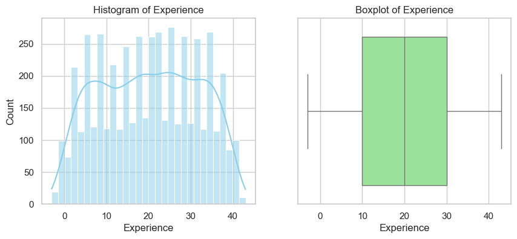

```python
# Plotting Experience variable to see the distribution.
plt.figure(figsize = (10,4))
plt.subplot(1,2,1)
sns.histplot(df["Experience"], kde = True, bins = 30, color = "skyblue")
plt.title("Histogram of Experience")

plt.subplot(1,2,2)
sns.boxplot(x=df["Experience"], color = "lightgreen")
plt.title("Boxplot of Experience")
plt.show()
```

### Observations:

The distribution of Experience appears to be approximately uniform, with employees spread fairly evenly across different experience levels ranging from 0 to about 40 years.

The histogram shows no significant skewness or outliers — counts remain relatively stable across the range, indicating a balanced representation of experience in the dataset.

The boxplot supports this observation — the median is around 20 years, and the interquartile range (IQR) spans roughly from 10 to 30 years.

There are no extreme outliers, and the whiskers extend close to the minimum and maximum values, further confirming a consistent spread of data.

```python
# In the previous analysis, it was observed that some experience values were negative (–), which are invalid and should not occur.
df["Experience"].unique()
```

```
array([ 1, 19, 15,  9,  8, 13, 27, 24, 10, 39,  5, 23, 32, 41, 30, 14, 18,
       21, 28, 31, 11, 16, 20, 35,  6, 25,  7, 12, 26, 37, 17,  2, 36, 29,
        3, 22, -1, 34,  0, 38, 40, 33,  4, -2, 42, -3, 43])
```

```python
# Replacing negative exprience with mean value.

mean_experience = df.loc[df['Experience'] >= 0, 'Experience'].mean()
mean_experience_rounded = round(mean_experience)
df.loc[df['Experience'] < 0, 'Experience'] = mean_experience_rounded
print(f"Rounded mean value used for replacement: {mean_experience_rounded}")
print(df['Experience'].describe())
```

```
Rounded mean value used for replacement: 20
count    5000.000000
mean       20.327600
std        11.253035
min         0.000000
25%        11.000000
50%        20.000000
75%        30.000000
max        43.000000
Name: Experience, dtype: float64
```

```python
df.head()
```

|  | ID | Age | Experience | Income | ZIPCode | Family | CCAvg | Education | Mortgage | Personal_Loan | Securities_Account | CD_Account | Online | CreditCard |
| --- | --- | --- | --- | --- | --- | --- | --- | --- | --- | --- | --- | --- | --- | --- |
| 0 | 1 | 25 | 1 | 49 | 91107 | 4 | 1.6 | 1 | 0 | 0 | 1 | 0 | 0 | 0 |
| 1 | 2 | 45 | 19 | 34 | 90089 | 3 | 1.5 | 1 | 0 | 0 | 1 | 0 | 0 | 0 |
| 2 | 3 | 39 | 15 | 11 | 94720 | 1 | 1.0 | 1 | 0 | 0 | 0 | 0 | 0 | 0 |
| 3 | 4 | 35 | 9 | 100 | 94112 | 1 | 2.7 | 2 | 0 | 0 | 0 | 0 | 0 | 0 |
| 4 | 5 | 35 | 8 | 45 | 91330 | 4 | 1.0 | 2 | 0 | 0 | 0 | 0 | 0 | 1 |

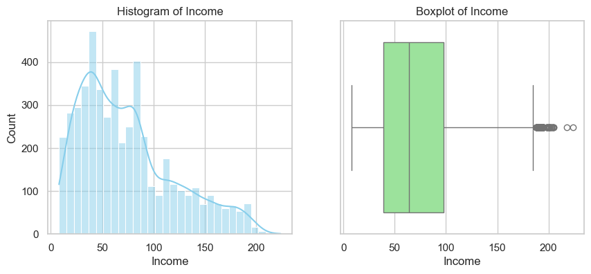

```python
# Plotting Income variable to see the distribution.
plt.figure(figsize = (10,4))
plt.subplot(1,2,1)
sns.histplot(df["Income"], kde = True, bins = 30, color = "skyblue")
plt.title("Histogram of Income")

plt.subplot(1,2,2)
sns.boxplot(x=df["Income"], color = "lightgreen")
plt.title("Boxplot of Income")
plt.show()
```

### Observations:

The distribution of Income is right-skewed (positively skewed) — most individuals earn lower to moderate income, while a smaller number earn significantly higher incomes.

The histogram shows that a large concentration of incomes lies roughly between 20K and 80K, after which the frequency gradually decreases.

The boxplot confirms this skewness, with a longer upper whisker and several high-income outliers beyond approximately 150K–200K.

The median income lies below the center of the box, further indicating that the majority of the population earns less than the average (mean) income.

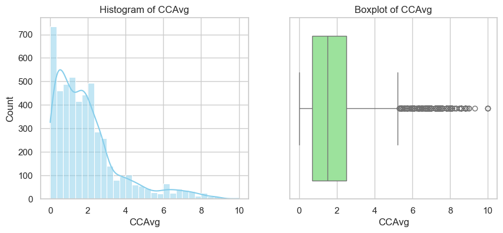

```python
# Plotting CCAvg variable to see the distribution.
plt.figure(figsize = (10,4))
plt.subplot(1,2,1)
sns.histplot(df["CCAvg"], kde = True, bins = 30, color = "skyblue")
plt.title("Histogram of CCAvg")

plt.subplot(1,2,2)
sns.boxplot(x=df["CCAvg"], color = "lightgreen")
plt.title("Boxplot of CCAvg")
plt.show()
```

### Observation:

The distribution of CCAvg (Credit Card Average spending) is highly right-skewed (positively skewed) — most customers have low average credit card spending, while a few customers spend significantly higher amounts.

The histogram shows that a large number of customers have CCAvg values between 0 and 2K, and the frequency sharply declines as the CCAvg increases.

The median lies toward the lower end of the distribution, suggesting that the majority of customers spend below the average level.

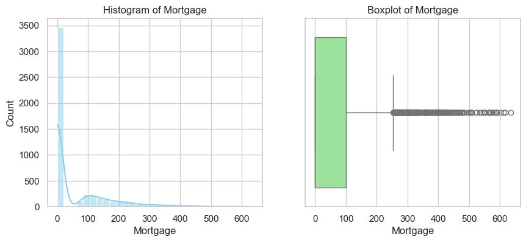

```python
# Plotting Mortgage variable to see the distribution.
plt.figure(figsize = (10,4))
plt.subplot(1,2,1)
sns.histplot(df["Mortgage"], kde = True, bins = 30, color = "skyblue")
plt.title("Histogram of Mortgage")

plt.subplot(1,2,2)
sns.boxplot(x=df["Mortgage"], color = "lightgreen")
plt.title("Boxplot of Mortgage")
plt.show()
```

### Observation:

The distribution of Mortgage is highly right-skewed (positively skewed) — the majority of customers have low or zero mortgage values, while a few have very high mortgage amounts.

The histogram shows a large spike near 0, indicating that most individuals do not have any mortgage, followed by a sharp decline as mortgage values increase.

The boxplot supports this pattern, with a long upper whisker and a large number of high-value outliers extending beyond approximately 300K, representing customers with exceptionally high mortgage amounts.

The median mortgage value lies toward the lower end of the distribution, emphasizing that most customers have relatively small or no mortgage debt.

## Bivariate Analysis

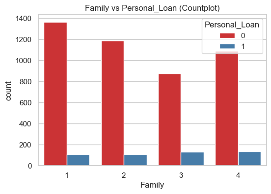

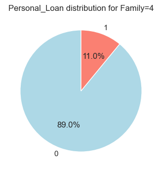

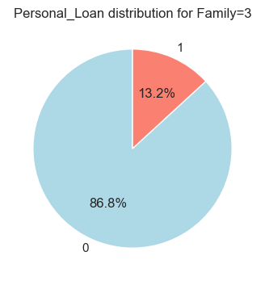

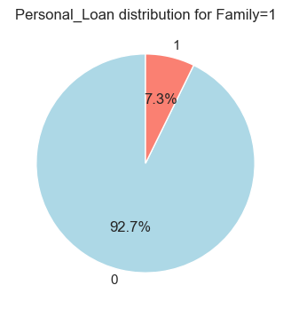

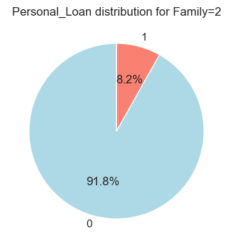

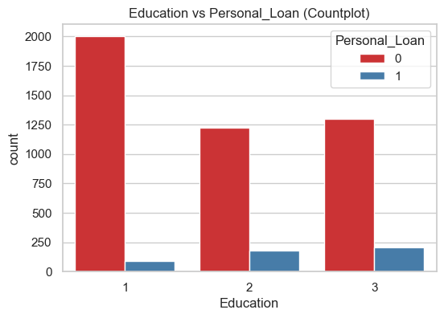

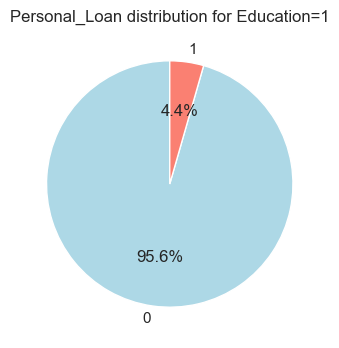

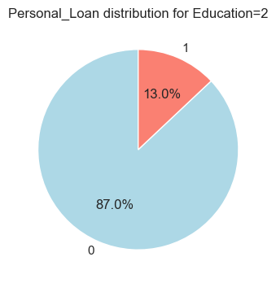

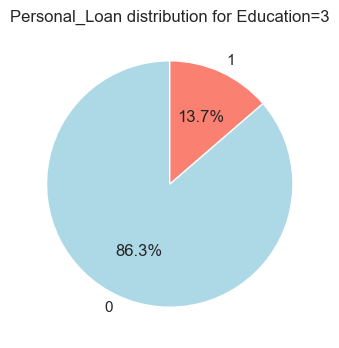

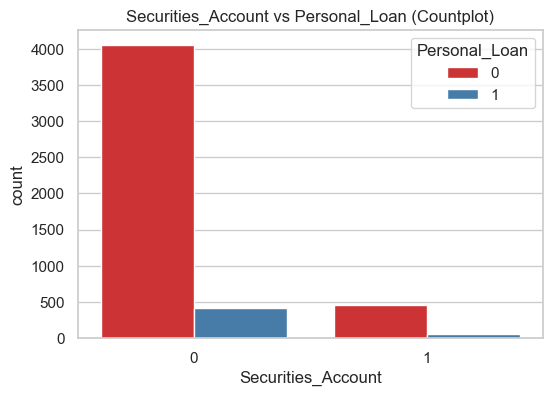

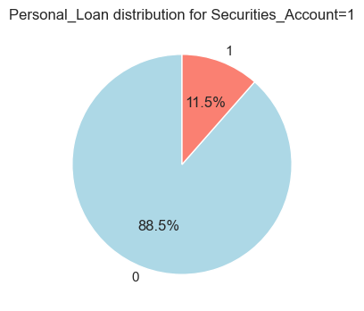

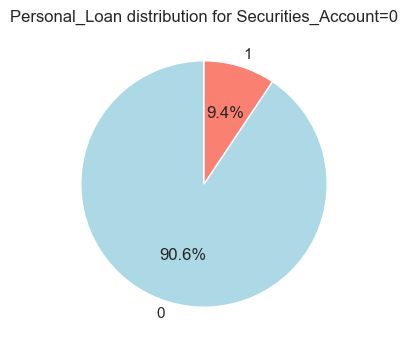

[9 more figures not shown]

```python
categorical_cols = ['Family','Education','Personal_Loan','Securities_Account','CD_Account','Online','CreditCard']
target = 'Personal_Loan'

# Categorical vs Target (countplots + pie charts)
for col in categorical_cols:
    if col != target:
        plt.figure(figsize=(6,4))
        sns.countplot(data=df, x=col, hue=target, palette="Set1")
        plt.title(f'{col} vs {target} (Countplot)')
        plt.show()

        # Pie chart of target distribution for each category
        for val in df[col].unique():
            subset = df[df[col]==val][target].value_counts()
            plt.figure(figsize=(4,4))
            subset.plot.pie(autopct='%1.1f%%', colors=['lightblue','salmon'], startangle=90)
            plt.ylabel('')
            plt.title(f'{target} distribution for {col}={val}')
            plt.show()
```

### Observations:

**1. Family vs Personal Loan**

Customers with family size = 1 or 2 are less likely to have taken a personal loan (loan acceptance rate around 7–8%).

The likelihood of taking a personal loan increases slightly for families with 3 or 4 members (loan acceptance around 11–13%).

Overall, customers with larger family sizes tend to have higher chances of personal loan acceptance, possibly due to increased financial needs.

**2. Education vs Personal Loan**

Education level 1 (Undergraduate) customers have the lowest loan acceptance rate (≈4–5%).

Education level 2 (Graduate) customers show moderate acceptance (≈13%).

Hence, loan acceptance increases with education level, suggesting that more educated individuals are more likely to take or qualify for a personal loan.

**3. Securities Account vs Personal Loan**

Customers without a securities account (0) have a loan acceptance rate of about 9.5%.

Those with a securities account (1) have a slightly higher acceptance rate of 11.5%.

Having a securities account shows a positive correlation with personal loan acceptance, possibly reflecting higher financial literacy or investment activity.

**4. CD Account vs Personal Loan**

A very strong relationship is observed here.

Customers without a CD account (0) have a low loan acceptance rate (7%), while those with a CD account (1) have a very high acceptance rate (46%).

This suggests that holding a CD account is a key indicator of customers more likely to avail personal loans, possibly due to stronger banking relationships or higher financial credibility.

**5. Online vs Personal Loan**

Loan acceptance rates are similar between those who use online banking and those who don’t.

Customers not using online services (0) have a loan acceptance rate of 9.4%, while those using online banking (1) have a slightly higher rate (9.8%).

The impact of online usage on loan acceptance is minimal, indicating it may not be a significant differentiator.

**6. CreditCard vs Personal Loan**

Customers without a credit card (0) show a loan acceptance rate of 9.5%, and those with a credit card (1) have a similar rate (~9.7%).

This suggests no significant relationship between having a credit card and taking a personal loan.

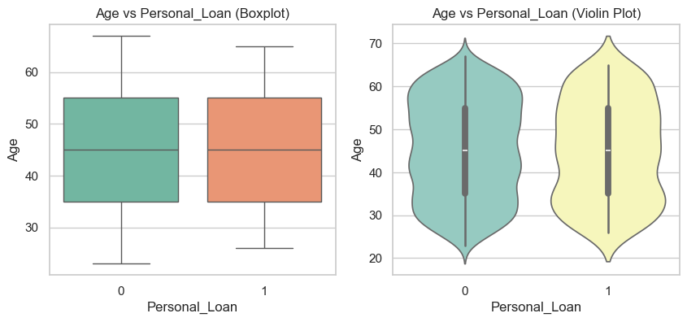

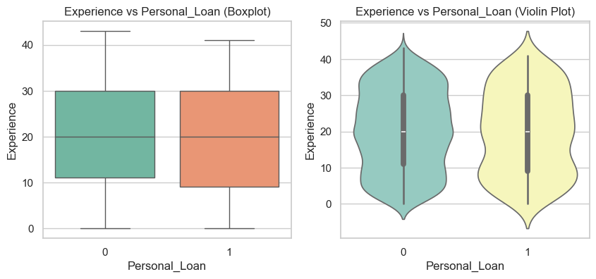

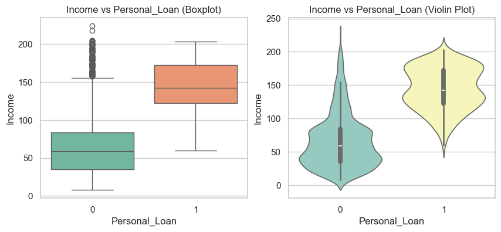

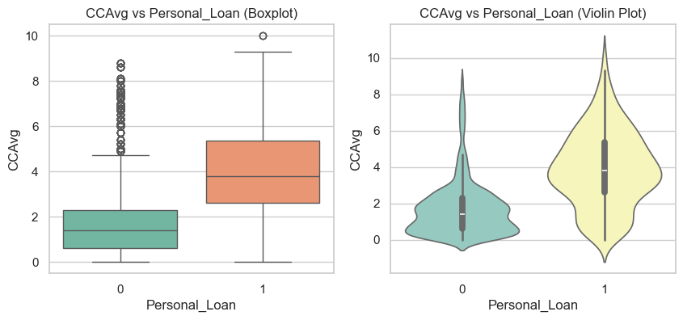

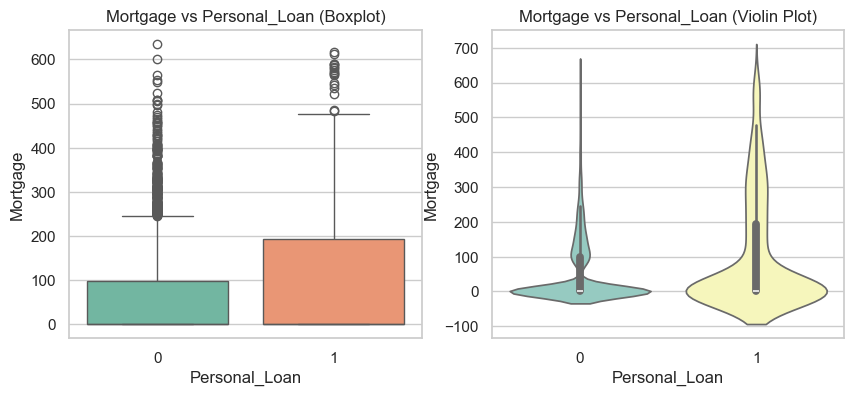

```python
numerical_cols = ['Age','Experience','Income','CCAvg','Mortgage']
target = 'Personal_Loan'

# Numerical vs Target (boxplots + violin plots)
for col in numerical_cols:
    plt.figure(figsize=(10,4))
    plt.subplot(1,2,1)
    sns.boxplot(x=df[target], y=df[col], palette="Set2")
    plt.title(f'{col} vs {target} (Boxplot)')

    plt.subplot(1,2,2)
    sns.violinplot(x=df[target], y=df[col], palette="Set3")
    plt.title(f'{col} vs {target} (Violin Plot)')
    plt.show()
```

### Observation:

**1. Age vs Personal_Loan**

The age distribution for both groups (loan taken = 1, loan not taken = 0) is fairly similar.

**2. Experience vs Personal_Loan**

The experience pattern follows a trend similar to age.

**3. Income vs Personal_Loan**

A strong positive relationship is visible between income and loan acceptance.

Customers who accepted personal loans have significantly higher incomes, as shown by both boxplot and violin plot.

This indicates that income is a key differentiator — higher-income customers are more likely to qualify for or choose personal loans.

**4. CCAvg (Credit Card Average Spending) vs Personal_Loan**

Customers with higher average monthly credit card spending are much more likely to take a personal loan.

The median CCAvg for loan takers is clearly higher, with a wider distribution extending into higher values.

This suggests that spending behavior is a strong predictor of loan acceptance, as high spenders might need additional credit support.

**5. Mortgage vs Personal_Loan**

Customers with a higher mortgage value tend to be more likely to take a personal loan.

This suggests that individuals with existing financial liabilities (like mortgages) may also opt for personal loans for liquidity or debt consolidation.

[output not shown]

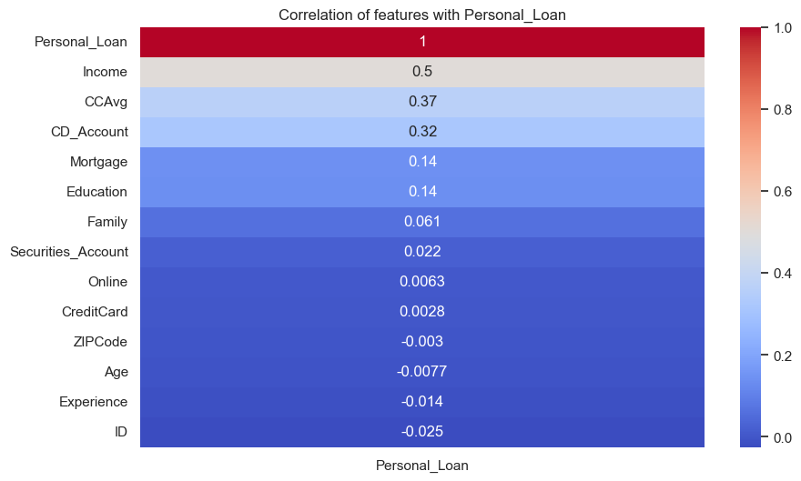

```python
# Correlation of numerical features with target
corr = df.corr()
plt.figure(figsize=(10,6))
sns.heatmap(corr[[target]].sort_values(by=target, ascending=False), annot=True, cmap="coolwarm")
plt.title(f'Correlation of features with {target}')
plt.show()
```

### Observation:

The feature Income shows the strongest positive correlation (0.5) with Personal_Loan, indicating that customers with higher income are more likely to accept a personal loan.

CCAvg (Credit Card Average Spending) also shows a moderately strong positive correlation (0.37), suggesting that customers with higher spending behavior are more inclined to take personal loans.

CD_Account has a positive correlation (0.32), implying that customers holding Certificate of Deposit accounts are more likely to have personal loans.

Mortgage (0.14) and Education (0.14) have weak but noticeable positive correlations, meaning customers with higher education and some mortgage obligations may have a slightly higher likelihood of taking personal loans.

Other variables such as Family (0.06), Securities_Account (0.02), Online (0.006), and CreditCard (0.0028) have negligible correlations, indicating minimal influence on loan acceptance.

Features like Age (-0.0077), Experience (-0.014), and ZIPCode (-0.003) show almost no correlation with personal loan decisions.

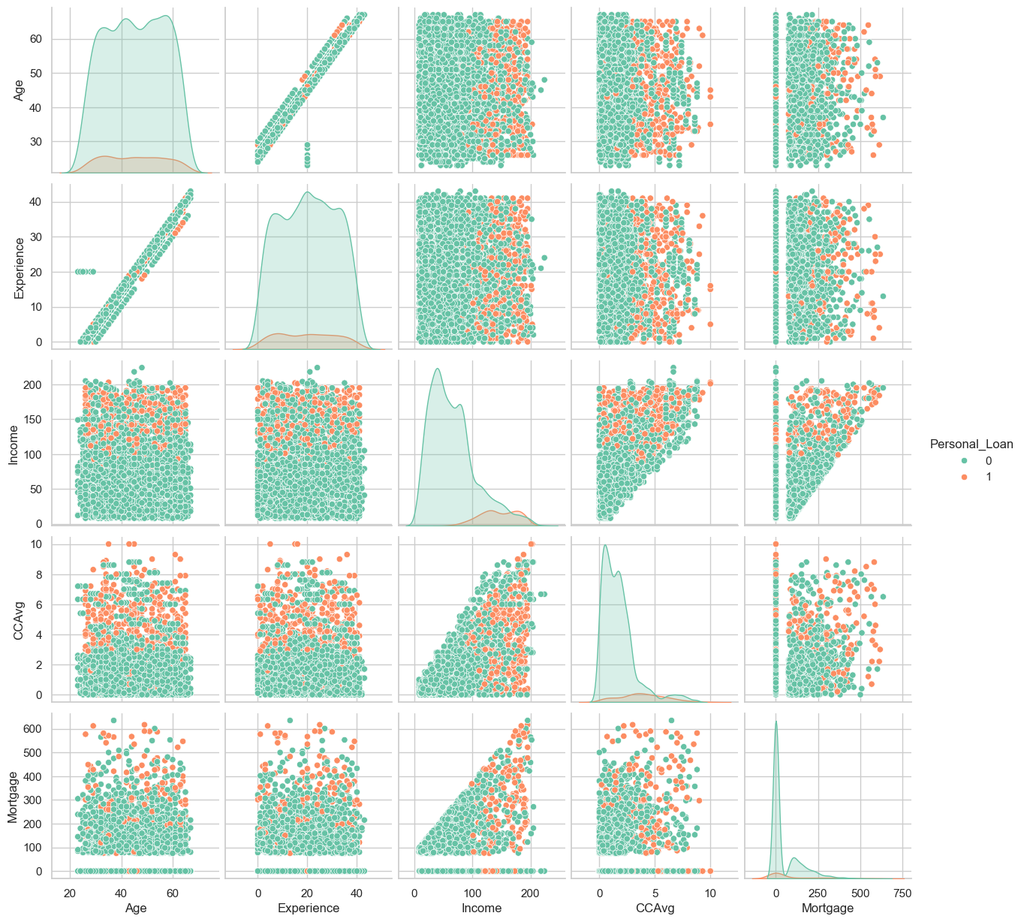

```python
# Pairplot for numerical features colored by target
sns.pairplot(df[numerical_cols + [target]], hue=target, palette="Set2")
plt.show()
```

### Observation:

**1. General Pattern**

The green points represent customers who did not take a personal loan (Personal_Loan = 0), while the orange points represent those who accepted a personal loan (Personal_Loan = 1).

The orange points (loan takers) are less frequent compared to non-loan takers, indicating that personal loan acceptance is relatively low in the dataset.

**2. Income vs Personal Loan**

There is a clear upward trend — most customers who accepted the loan (orange) fall into the higher income range (above 100).

This confirms a strong positive relationship between income and loan acceptance, as higher-income customers are more likely to take or qualify for personal loans.

**3. CCAvg vs Personal Loan**

A strong positive pattern is visible between CCAvg (credit card spending) and loan acceptance.

Customers with higher average credit card spending (above 3–4) show a greater tendency to have personal loans.

This aligns with earlier findings — high spenders are more likely to opt for additional credit.

**4. Mortgage vs Personal Loan**

Customers with moderate to high mortgage values (100–300) show a slightly higher concentration of loan takers.

However, most data points are clustered near zero, suggesting that a majority have no or low mortgage, and only a few high-mortgage customers overlap with personal loan acceptance.

**5. Age and Experience vs Personal Loan**

Both Age and Experience show no clear linear trend with loan acceptance.

Loan takers (orange) are spread across all age and experience levels, though slightly more concentrated in middle age groups (30–50 years).

This indicates that age and experience are not strong predictors for personal loan acceptance.

**6. Variable Relationships**

Income and CCAvg show a positive linear relationship, indicating that customers with higher income tend to spend more on credit cards.

Age and Experience are highly correlated, which is expected as more experienced customers are generally older.

Other variables like Mortgage, Age, and Income show weak relationships, suggesting they vary independently.

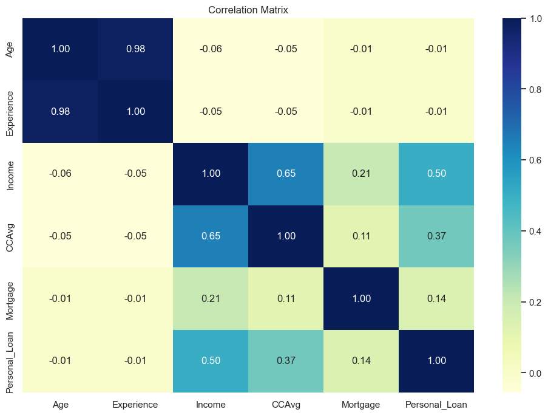

```python
# Heatmap of correlations between all numerical features
plt.figure(figsize=(12,8))
sns.heatmap(df[numerical_cols + [target]].corr(), annot=True, fmt=".2f", cmap="YlGnBu")
plt.title("Correlation Matrix")
plt.show()
```

### Observations:

**1. Strong Correlations**

Age and Experience show an extremely strong positive correlation (0.98) — this is expected since experience generally increases with age.

Income and CCAvg (Credit Card Average Spending) have a strong positive correlation (0.65) — customers with higher income tend to spend more on credit cards.

**2. Moderate Correlations**

Income and Personal_Loan have a moderate positive correlation (0.50), indicating that higher income customers are more likely to take personal loans.

CCAvg and Personal_Loan also show a moderate positive correlation (0.37) — customers who spend more on credit cards are more inclined to accept personal loans.

Income and Mortgage show a weak to moderate correlation (0.21), suggesting that higher-income individuals might also have slightly larger mortgages.

**3. Weak or No Correlations**

Mortgage and Personal_Loan show a weak positive correlation (0.14) — meaning mortgage value has only a minor influence on loan acceptance.

Age and Experience both have very weak negative correlations with Income, CCAvg, and Personal_Loan, implying that age or work experience has minimal impact on the likelihood of taking a personal loan.